# Chapter 07 Problem Set Key

## 1. Bring a flow diagram to class on Thursday (Nov. 16)

Please do a literature search for a disease model. Find one with a flow diagram and do a “show and tell” for class on Thursday (Nov. 16), explaining the variables and how it relates to the model of differential equations. Send me the paper before class. For this problem, include the image from the paper of both the diagram and system of equations. Include one for each of you. Give a brief description (3—4 sentences) on what is being show.

> Have two diagrams, set of equatiosn, and short descriptions

## 2. (Exercise 7.4 from the book)

The proportion of *Daphnia* infected during a period of 15 days is, in sequence, 0.01, 0.03, 0.03, 0.1, 0.14, 0.3, 0.3, 0.58, 0.7, 0.7, 0.92, 0.92, 0.96, 0.97, 099, 0.99. Plot the time series.

Superimpose the integrated form of the equation (from Exercise 7.4), and manually change $\beta$ until you have a good fit. What is the transmission rate that you find?

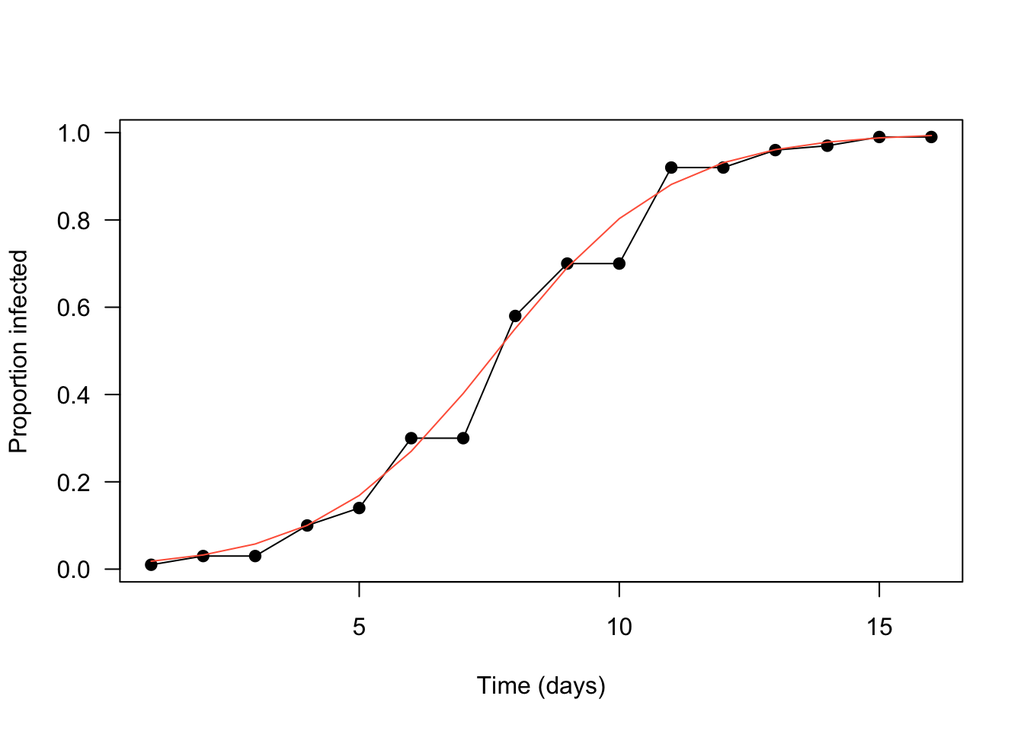

> ```r
> infected <- c(0.01, 0.03, 0.03, 0.1, 0.14, 0.3, 0.3, 0.58, 0.7, 0.7, 0.92, 0.92, 0.96, 0.97, 0.99, 0.99)
> days <- 1:length(infected)
>
> I0 <- infected[1]
> beta <- 0.6
> It <- I0/((1 - I0)*exp(-beta*days) + I0)
>
> plot(x = days, y = infected, xlab = "Time (days)", ylab = "Proportion infected", las = 1, type = "l")
>   points(x = days, y = infected, pch = 19)
>   lines(col = "tomato", x = days, y = It)
> ```

> I eyeballed a transmission rate of $\beta = 0.6$. For fun, let’s use R’s non-linear least-squares estimator:

> ```r
> nls_out <- nls(formula = infected ~ I0/((1 - I0)*exp(-beta*days) + I0), start = c(beta = 0.6))
> coefficients(nls_out)
> ```

> ```
> ##      beta
> ## 0.5877171
> ```

## 3. (Exercise 7.15 from the book)

Suppose that individuals can be switched directly from susceptible to resistant without having to become infected. How would that affect equations 4a and 4c?

3.1. Write down what the right-hand side of the equations:
$$\frac{\mathrm{d}S}{\mathrm{d}t} = \\
\frac{\mathrm{d}R}{\mathrm{d}t} =$$

> $$\begin{aligned}\frac{\mathrm{d}S}{\mathrm{d}t}
> &= -\beta SI - \delta S\\
> \frac{\mathrm{d}I}{\mathrm{d}t} &= \beta SI - \nu I \\
> \frac{\mathrm{d}R}{\mathrm{d}t} &= \nu I + \delta S
> \end{aligned}$$

3.2. What is this modeling (i.e., how to the susceptible become resistant without being infected)?

> Susceptibles becoming resitant without being infecetd could be modeling behavior that avoid infected or, perhaps more stright-forward, would be immunity aquired from a vaccine.